# Gráfico de RidgeLine

Luis Armando Méndez Espinosa

2026-03-24

#### * También es conocida como Joyplot

#### * Su uso moderno fue popularizado por Claus Wilke quien es el desarrollador del paquete ggridges para Lenguaje R

#### * Requiere de variables cuantitativas continuas con multiples observaciones por grupo y variables de agrupación o categorías

#### * Permite comparar distribuciones completas, muestra en un solo gráfico la dispersión, simetría y concentración de varios grupos de observaciones

#### * Como inconvenientes encuentro que puede ser dificil de interpretar para usuarios no técnicos

#### * Las aplicaciones comunes pueden ser: comparativo de distribución de ingresos por año, temperaturas por mes, evolución de precios en el tiempo, cambios de patrones de consumo

### Ejemplo en Lenguaje R

##### Cargar librerías

```r
library( readr )
library( dplyr )
library( ggplot2 )
library( ggridges )
library( scales )
```

##### Cargar los datos del archivo CSV

```r
datos <- read_csv("~/Documents/Educación/Maestría UOC/3) Visualización de Datos/PEC 2/PEC2/Precios.csv")
```

##### Realizar transformaciones para asegurar tipos de datos correctos

```r
datos <- datos %>%
  mutate(
    Fecha     = as.Date(Fecha),
    Ejercicio = factor(Ejercicio, levels = sort(unique(Ejercicio))),
    Precio   = as.numeric(Precio)
  ) %>%
  filter(!is.na(Precio), Precio > 0)
```

##### Mostrar la cantidad de observaciones del dataset

```r
nrow( datos )
```

```
## [1] 1815
```

##### Crear gráfico de Ridgeline mediante la función ggplot

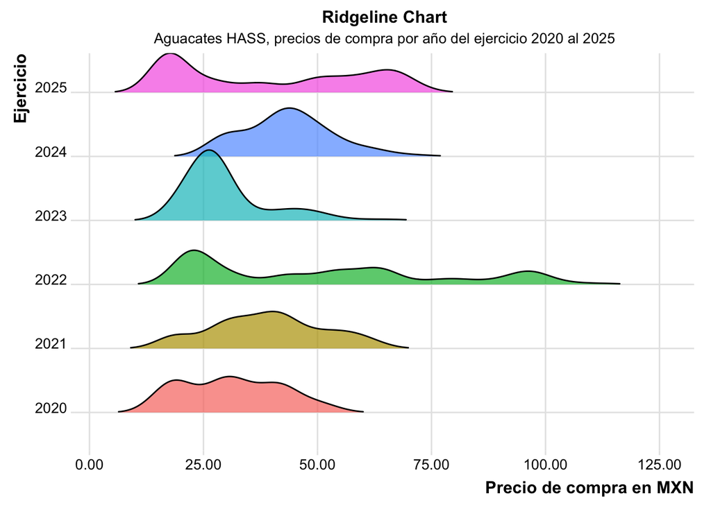

```r
ggplot(datos, aes(x = Precio, y = Ejercicio, fill = Ejercicio)) +

  geom_density_ridges(
    alpha          = 0.7,
    scale          = 1.1,
    rel_min_height = 0.01,
    size           = 0.35
  ) +

  labs(
    title    = "Ridgeline Chart",
    subtitle = "Aguacates HASS, precios de compra por año del ejercicio 2020 al 2025",
    x        = "Precio de compra en MXN",
    y        = "Ejercicio"
  ) +

  scale_x_continuous(labels = comma_format(accuracy = 0.01)) +

  theme_ridges(font_size = 12, grid = TRUE) +

  theme(
    legend.position = "none",
    plot.title      = element_text(hjust = 0.5, face = "bold"),
    plot.subtitle   = element_text(hjust = 0.5),
    axis.title      = element_text(face = "bold")
  )
```

#### Se observa que algunos años presentan distribuciones más concentradas, lo que indica mayor estabilidad, mientras que otros muestran mayor dispersión, reflejando volatilidad en el mercado.

#### Además, se identifican desplazamientos hacia valores más altos en ciertos años, lo que sugiere cambios estructurales en el nivel de precios.

#### La técnica permite analizar no solo el promedio, sino la forma completa de la distribución, lo cual no sería posible con gráficos tradicionales como líneas o barras.